# Practical Machine Learning Project

Joseph Coggins

September 26, 2015

# Introduction

This is homework assignment for Coursera course Practical Machine Learning. The course is provided by John Hopkins University.

The scripts used were write on a PC, using RStudio Version 0.99.484.

My GitHub repos are located at: https://github.com/jcoggins

This assignment is located at: https://github.com/jcoggins/Practical-Machine-Learning-Project/blob/master/ML_Project_JCoggins.html

## Background:

Using devices such as Jawbone Up, Nike FuelBand, and Fitbit it is now possible to collect a large amount of data about personal activity relatively inexpensively. These type of devices are part of the quantified self movement - a group of enthusiasts who take measurements about themselves regularly to improve their health, to find patterns in their behavior, or because they are tech geeks. One thing that people regularly do is quantify how much of a particular activity they do, but they rarely quantify how well they do it. In this project, your goal will be to use data from accelerometers on the belt, forearm, arm, and dumbell of 6 participants. They were asked to perform barbell lifts correctly and incorrectly in 5 different ways. More information is available from the website here: http://groupware.les.inf.puc-rio.br/har (see the section on the Weight Lifting Exercise Dataset).

The machine learning package is the caret package. The ggplot2 package is a good standardized plotting package.

```r
library(ggplot2)
library(caret)
set.seed(34323)
```

## Data Sources

Machine training source: “https://d396qusza40orc.cloudfront.net/predmachlearn/pml-training.csv”

Test data on machine source: “https://d396qusza40orc.cloudfront.net/predmachlearn/pml-testing.csv”

## Goal

The purpose of the project is to train a machine with an accuracy of prediction of greater than 90%. The classe variable is used for the prediction. Cross-validation and out of sample error should be shown. The predication model choose should successfully predict the classe values for the 20 possible submissions.

Here is the URL path to the training.csv file

```r
trainingURL = "https://d396qusza40orc.cloudfront.net/predmachlearn/pml-training.csv"
```

Here is the URL path to the testing.csv file

```r
testingURL = "https://d396qusza40orc.cloudfront.net/predmachlearn/pml-testing.csv"
```

Extracting the csv files Now we can read the csv files into memory training

```r
training = read.csv(url(trainingURL),, header=T, sep=",", na.strings=c("NA", "#DIV/0!", ""))
```

testing

```r
testing = read.csv(url(testingURL), header=T, sep=",", na.strings=c("NA", "#DIV/0!", ""))
```

Exploratory Analysis:

```r
#summary(training, 5)
#head(training, 5)
#names(training)
```

The head() without using na.strings shows NA, blanks, #Div/0! and near zero data. This data should be cleaned from the training data to train the machine on clean data. Colums without data should be removed as well.

Let’s Partition the given Training Data

```r
inTrain = createDataPartition(y=training$classe, p=0.7, list=FALSE)
trainingData = training[inTrain,]
testingData = training[-inTrain,]
dim(trainingData)
```

```
## [1] 13737   160
```

```r
dim(testingData)
```

```
## [1] 5885  160
```

Determine the datatype for each column

```r
#sapply(trainingData, class)
```

## Cleaning Data

Cleaning out columns with near zero variance

```r
nzv = nearZeroVar(trainingData, saveMetrics = TRUE)
trainingData = trainingData[,nzv$nzv==FALSE]

nzv = nearZeroVar(testingData, saveMetrics = TRUE)
testingData = testingData[,nzv$nzv==FALSE]

#head(trainingData)
```

## Data Transformation

Create another subset

```r
trainingData = trainingData[c(-1)]

trainingDataA = trainingData
for(i in 1:length(trainingData)) {
  if(sum(is.na(trainingData[,i])) /nrow(trainingData) >= 0.60) {
    for(j in 1:length(trainingDataA)) {
      if(length( grep(names(trainingData[i]), names(trainingDataA)[j])) == 1){
        trainingDataA = trainingDataA[, -j]
      }
    }
  }
}

trainingData = trainingDataA
dim(trainingData)
```

```
## [1] 13737    58
```

## Cleaning and Transforming Test Data

Cleanup the testingData and testing data sets

```r
removeA = colnames(trainingData)  # 60% column removal
removeB = colnames(trainingData[, -58]) # removes the classe column (last column)
testingData = testingData[removeA]
testing = testing[removeB]
dim(testingData)
```

```
## [1] 5885   58
```

```r
dim(testing)
```

```
## [1] 20 57
```

## Coercing the Data

Coerce the data into the same type

```r
for(i in 1:length(testing)) {
  for(j in 1:length(trainingData)) {
    if(length(grep(names(trainingData[i]), names(testing)[j]))== 1) {
      class(testing[j]) = class(trainingData[i])
    }
  }
}

testing = rbind(trainingData[2, -58], testing)
testing = testing[-1,]
```

## First Plot

Data Plot

```
##
##    A    B    C    D    E
## 3906 2658 2396 2252 2525
```

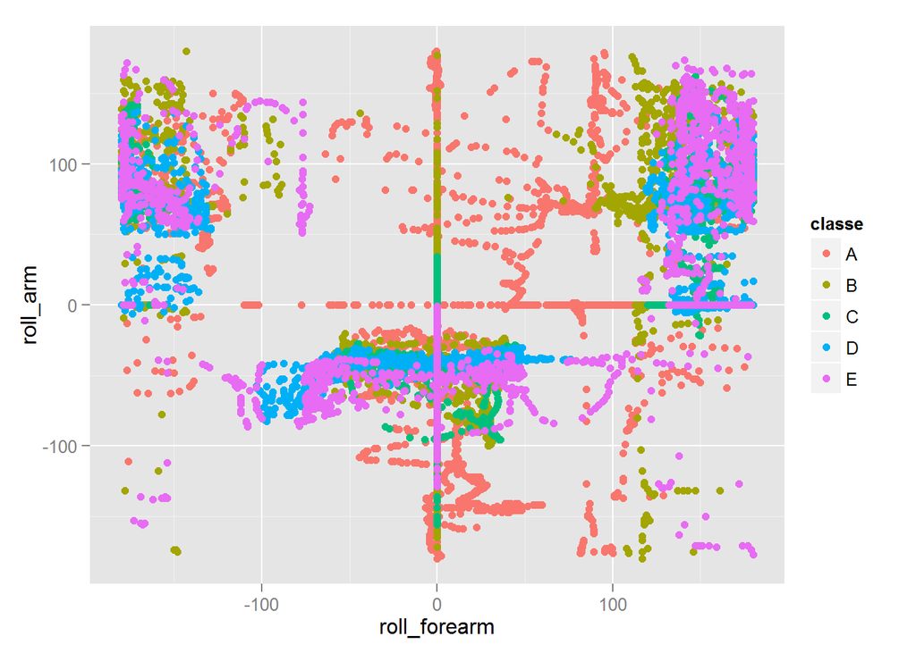

## Try Decision Tree

Decision Tree Plot

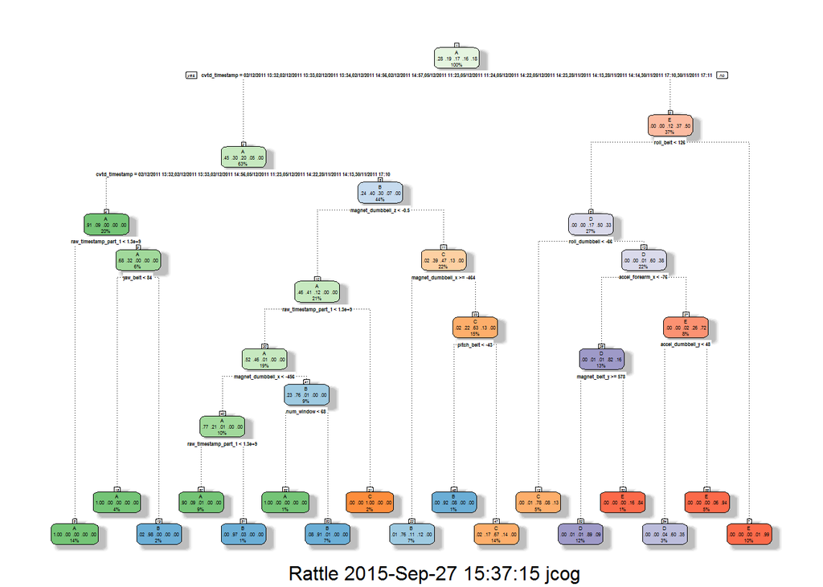

Prediction:

```r
prediction = predict(modFit, testingData, type="class")
table(prediction, testingData$classe)
```

```
##
## prediction    A    B    C    D    E
##          A 1611   49    5    1    0
##          B   52  957   67   39    0
##          C   11  123  939  160   46
##          D    0   10   15  723  162
##          E    0    0    0   41  874
```

Use confusion matrix to check Accuracy

```r
cmTree = confusionMatrix(prediction, testingData$classe)
cmTree
```

```
## Confusion Matrix and Statistics
##
##           Reference
## Prediction    A    B    C    D    E
##          A 1611   49    5    1    0
##          B   52  957   67   39    0
##          C   11  123  939  160   46
##          D    0   10   15  723  162
##          E    0    0    0   41  874
##
## Overall Statistics
##
##                Accuracy : 0.8673
##                  95% CI : (0.8584, 0.8759)
##     No Information Rate : 0.2845
##     P-Value [Acc > NIR] : < 2.2e-16
##
##                   Kappa : 0.8322
##  Mcnemar's Test P-Value : NA
##
## Statistics by Class:
##
##                      Class: A Class: B Class: C Class: D Class: E
## Sensitivity            0.9624   0.8402   0.9152   0.7500   0.8078
## Specificity            0.9869   0.9667   0.9300   0.9620   0.9915
## Pos Pred Value         0.9670   0.8583   0.7342   0.7945   0.9552
## Neg Pred Value         0.9851   0.9618   0.9811   0.9516   0.9581
## Prevalence             0.2845   0.1935   0.1743   0.1638   0.1839
## Detection Rate         0.2737   0.1626   0.1596   0.1229   0.1485
## Detection Prevalence   0.2831   0.1895   0.2173   0.1546   0.1555
## Balanced Accuracy      0.9747   0.9035   0.9226   0.8560   0.8996
```

Plot Decision Tree CM

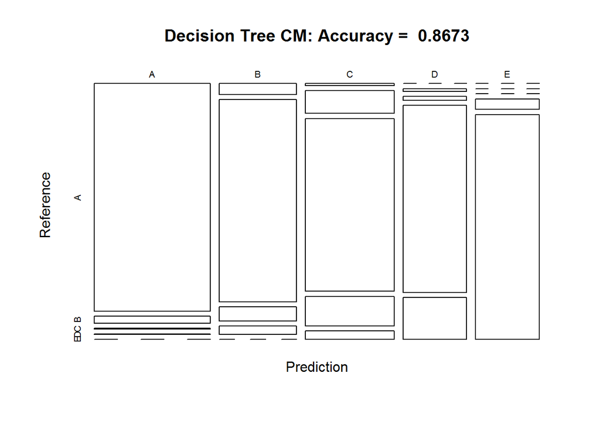

## Try Random Forests

Random Forests Prediction

```r
library(randomForest)
  modFitRF = randomForest(classe ~ ., data=trainingData)
  predictionRF = predict(modFitRF, testingData, type="class")
  cmRF = confusionMatrix(predictionRF, testingData$classe)
  cmRF
```

```
## Confusion Matrix and Statistics
##
##           Reference
## Prediction    A    B    C    D    E
##          A 1672    0    0    0    0
##          B    2 1139    1    0    0
##          C    0    0 1024    1    0
##          D    0    0    1  963    3
##          E    0    0    0    0 1079
##
## Overall Statistics
##
##                Accuracy : 0.9986
##                  95% CI : (0.9973, 0.9994)
##     No Information Rate : 0.2845
##     P-Value [Acc > NIR] : < 2.2e-16
##
##                   Kappa : 0.9983
##  Mcnemar's Test P-Value : NA
##
## Statistics by Class:
##
##                      Class: A Class: B Class: C Class: D Class: E
## Sensitivity            0.9988   1.0000   0.9981   0.9990   0.9972
## Specificity            1.0000   0.9994   0.9998   0.9992   1.0000
## Pos Pred Value         1.0000   0.9974   0.9990   0.9959   1.0000
## Neg Pred Value         0.9995   1.0000   0.9996   0.9998   0.9994
## Prevalence             0.2845   0.1935   0.1743   0.1638   0.1839
## Detection Rate         0.2841   0.1935   0.1740   0.1636   0.1833
## Detection Prevalence   0.2841   0.1941   0.1742   0.1643   0.1833
## Balanced Accuracy      0.9994   0.9997   0.9989   0.9991   0.9986
```

[figure not shown]

Plot Random Forests

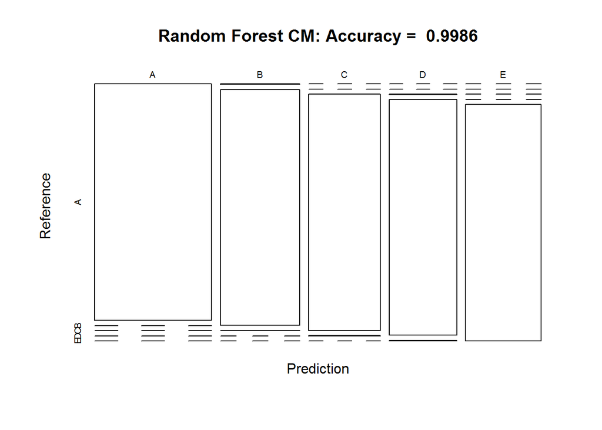

## Generating Submission Files based on the Prediction from Random Forests

Generating Files for Submission

```r
  predictionRF = predict(modFitRF, testing, type="class")

  pml_write_files = function(x) {
    n = length(x)
    for( i in 1:n){
      filename = paste0("problem_id_", i, ".txt")
      write.table(x[i], file=filename, quote=FALSE, row.names=FALSE, col.names=FALSE)
    }
  }

  pml_write_files(predictionRF)
```